# More more on Normal Distributions

your name

2024-10-10

## Math 2265 Sec 4.1 Normal Distribution Part III

- Work as a group!
- You will need to replace `"ans"` or `your_answer` in the source code or answer questions
- Update your name in L3
- Add your group members’ name below; students may lose one point if Q0 is unanswered
- Make sure you save and `knit` your work (to html or pdf) before submitting it to Canvas

### Goal

- Learn the function that computes the percentile from given x or its Z-score.
- Learn the function that computes x or its Z-score or from given percentile.
- Master the functions `pnorm` and `qnorm`.

### Question 0. Who are your group members? (List their first names should be sufficient)

**Answer:**

1. `<name_1>`
2. `<name_2>`

### If you need more time to get used to `Markdown`, use the `Visual` mode.

The icon is located in the upper-left corner next to `source`.

### Example 1: Visualizing percentiles in the normal distribution with `xpnorm`

1. P(Z < -1.1)

```r
xpnorm(-1.1, mean = 0, sd = 1)
```

```
## If X ~ N(0, 1), then
```

```
##  P(X <= -1.1) = P(Z <= -1.1) = 0.1357
```

```
##  P(X >  -1.1) = P(Z >  -1.1) = 0.8643
```

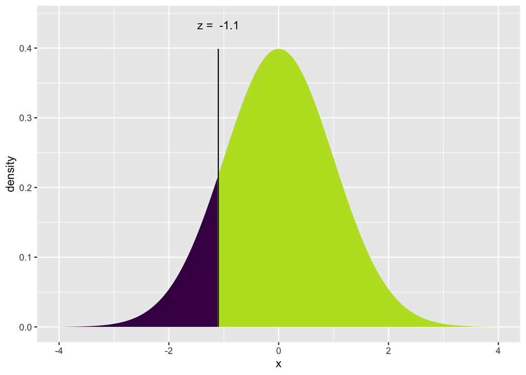

```
## [1] 0.1356661
```

2. P(Z < 0.35)

```r
xpnorm(0.35, mean = 0, sd = 1)
```

```
## If X ~ N(0, 1), then
```

```
##  P(X <= 0.35) = P(Z <= 0.35) = 0.6368
```

```
##  P(X >  0.35) = P(Z >  0.35) = 0.3632
```

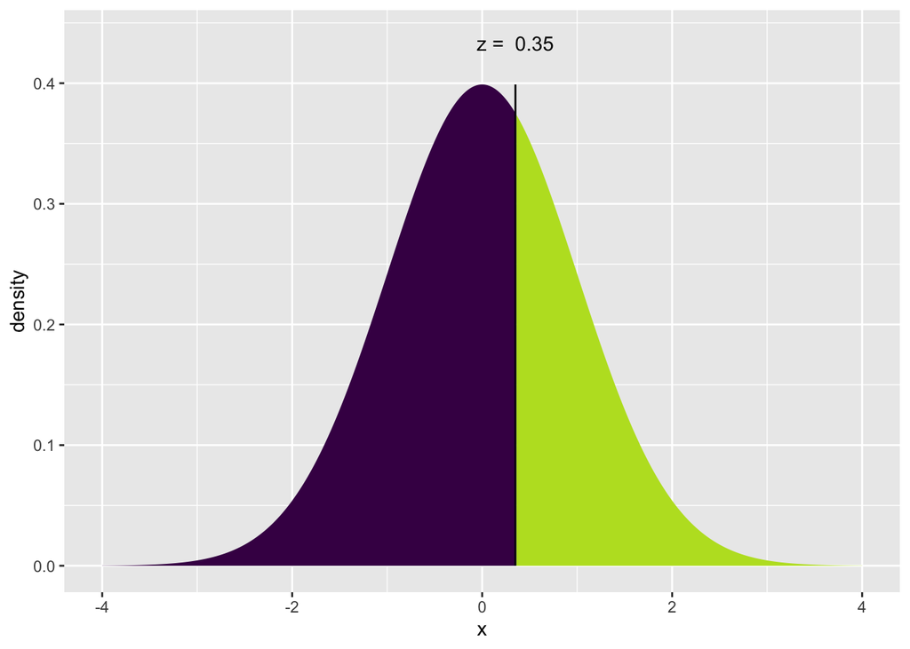

```
## [1] 0.6368307
```

3. P(Z > 0.5)

```r
xpnorm(0.5, mean = 0, sd = 1)
```

```
## If X ~ N(0, 1), then
```

```
##  P(X <= 0.5) = P(Z <= 0.5) = 0.6915
```

```
##  P(X >  0.5) = P(Z >  0.5) = 0.3085
```

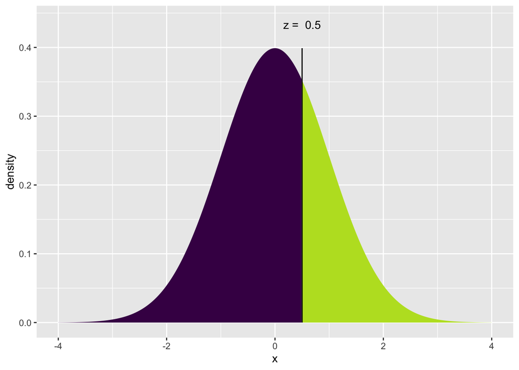

```
## [1] 0.6914625
```

Caveat: `xpnorm` computes both P(Z<0.5) and P(Z>0.5).

4. P(|Z| < 2) = P (-2 < Z < 2)

```r
xpnorm(c(-2,2), mean = 0, sd = 1)
```

```
## If X ~ N(0, 1), then
```

```
##  P(X <= -2) = P(Z <= -2) = 0.02275   P(X <=  2) = P(Z <=  2) = 0.97725
```

```
##  P(X >  -2) = P(Z >  -2) = 0.97725   P(X >   2) = P(Z >   2) = 0.02275
```

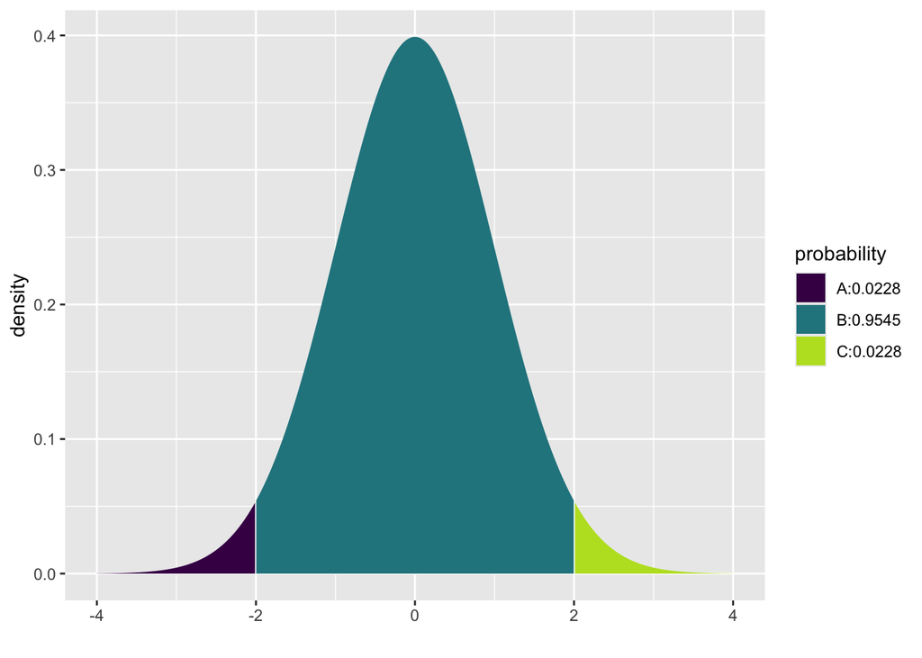

```
## [1] 0.02275013 0.97724987
```

Caveat: This does not compute P(|Z|< 2), but P(Z<-2) and P(Z<2) for -2, 2.

### Example 2: Visualizing percentiles in normal distributions with `xpnorm`

1. x = 98, $\mu = 92.6$, $\sigma = 3.6$

```r
xpnorm(98, mean=92.6, sd=3.6)
```

```
## If X ~ N(92.6, 3.6), then
```

```
##  P(X <= 98) = P(Z <= 1.5) = 0.9332
```

```
##  P(X >  98) = P(Z >  1.5) = 0.06681
```

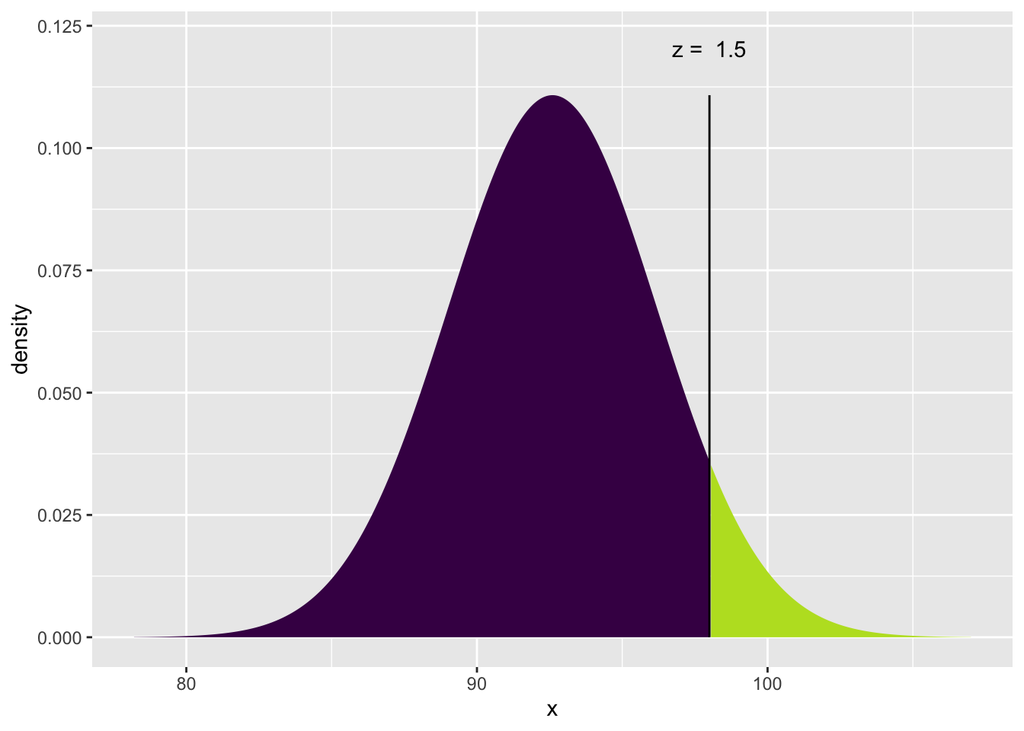

```
## [1] 0.9331928
```

Note that the Z-score, 1.5, is computed.

2. x = 89, $\mu = 92.6$, $\sigma = 3.6$

```r
xpnorm(89, mean=92.6, sd=3.6)
```

```
## If X ~ N(92.6, 3.6), then
```

```
##  P(X <= 89) = P(Z <= -1) = 0.1587
```

```
##  P(X >  89) = P(Z >  -1) = 0.8413
```

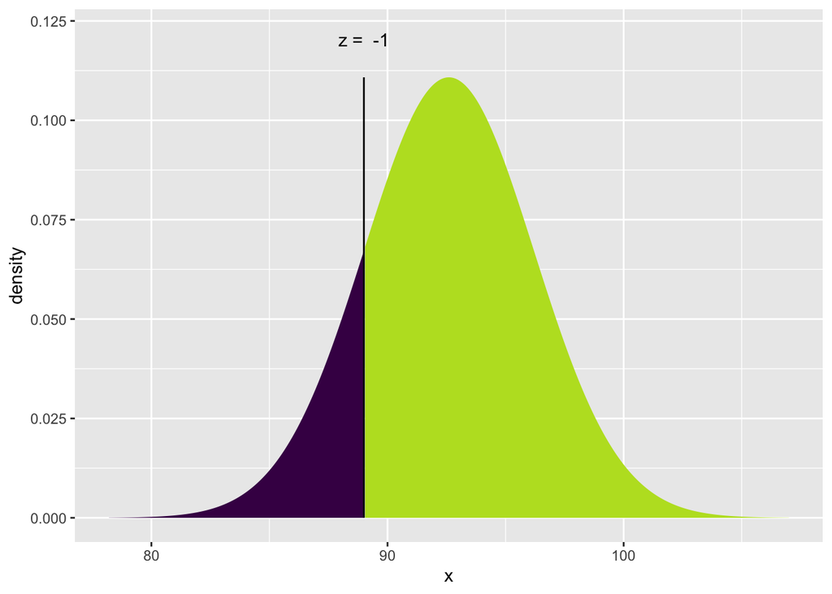

```
## [1] 0.1586553
```

### Example 3: Visualizing Z-scores from Percentages

What is the Z-score for the 80th percentile with mean = 0 and standard deviation = 1?

```r
qnorm(0.8, mean = 0, sd = 1)
```

```
## [1] 0.8416212
```

Now check out the output of `xqnorm`.

```r
xqnorm(0.8, mean = 0, sd = 1)
```

```
## If X ~ N(0, 1), then
```

```
##  P(X <= 0.8416212) = 0.8
```

```
##  P(X >  0.8416212) = 0.2
```

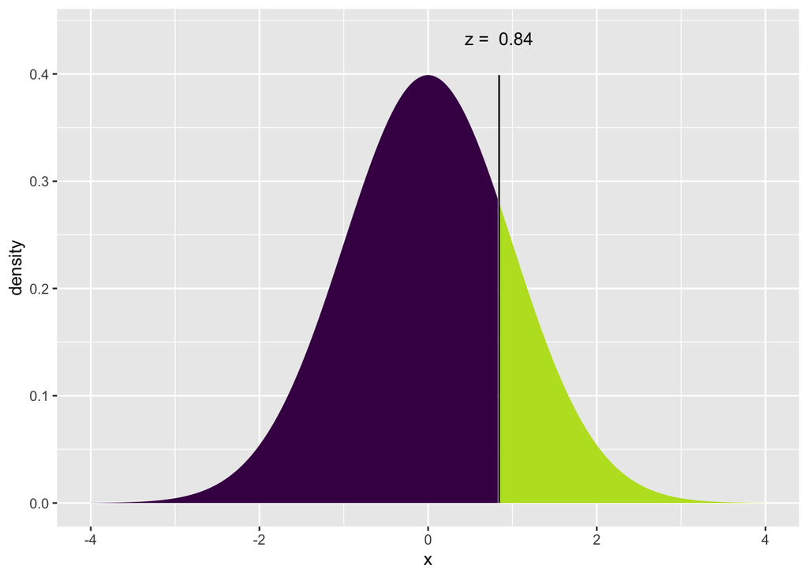

```
## [1] 0.8416212
```

## HW Problem

### Speeding on the I-5 Freeway

The distribution of passenger vehicle speeds traveling on the Interstate 5 Freeway (I-5) in California is nearly normal with:

- Mean speed ($\mu$): 72.6 miles/hour
- Standard deviation ($\sigma$): 4.78 miles/hour

### (a) What percent of passenger vehicles travel slower than 80 miles/hour?

First, compute the Z-score for $x = 80$:

```r
z_80 <- (80 - 72.6) / 4.78
z_80
```

```
## [1] 1.548117
```

Now, compute the percentile using the standard normal distribution:

```r
p_80 <- pnorm(z_80, mean = 0, sd = 1)
p_80
```

```
## [1] 0.939203
```

Alternatively, you can compute the percentile directly without calculating the Z-score:

```r
p_80_direct <- pnorm(80, mean = 72.6, sd = 4.78)
p_80_direct
```

```
## [1] 0.939203
```

### (b) What percent of passenger vehicles travel between 60 and 80 miles/hour?

```r
p_60_direct <- pnorm(60, mean = 72.6, sd = 4.78)
p_60_direct
```

```
## [1] 0.004194693
```

Compute the percentage (we already computed `p_80_direct` above).

```r
p_80_direct - p_60_direct
```

```
## [1] 0.9350083
```

### (c) How fast do the fastest 5% of passenger vehicles travel?

We need to find the speed corresponding to the 95th percentile (since the fastest 5% are above this speed).

Compute the speed using the inverse normal distribution function `qnorm`:

```r
speed_95th <- qnorm(0.95, mean = 72.6, sd = 4.78)
speed_95th
```

```
## [1] 80.4624
```

### (d) Approximate what percentage of the passenger vehicles travel above the speed limit of 70 miles/hour.

Compute the Z-score for $x = 70$:

```r
z_70 <- (70 - 72.6) / 4.78
z_70
```

```
## [1] -0.5439331
```

Compute the cumulative probability up to 70 miles/hour:

```r
p_70 <- pnorm(z_70, mean = 0, sd = 1)
p_70
```

```
## [1] 0.2932438
```

Alternatively, compute directly:

```r
p_70_direct <- pnorm(70, mean = 72.6, sd = 4.78)
p_70_direct
```

```
## [1] 0.2932438
```

Compute the percentage of vehicles traveling above 70 miles/hour:

```r
percent_above_70 <- (1 - p_70) * 100
percent_above_70
```

```
## [1] 70.67562
```

### Task 6. Knit your code and check your outcomes.

You are only allowed to upload pdf or html

### Task 7. Check your answer

```r
if(percent_above_70-0.9544997<0.00005) {
  print("Your answer is correct")
} else {
  print("Check your answer")
}
```

```
## [1] "Check your answer"
```

### Share your work and help your group members before uploading your work to Canvas